# ChromeQC: Library Quality of Linked Reads

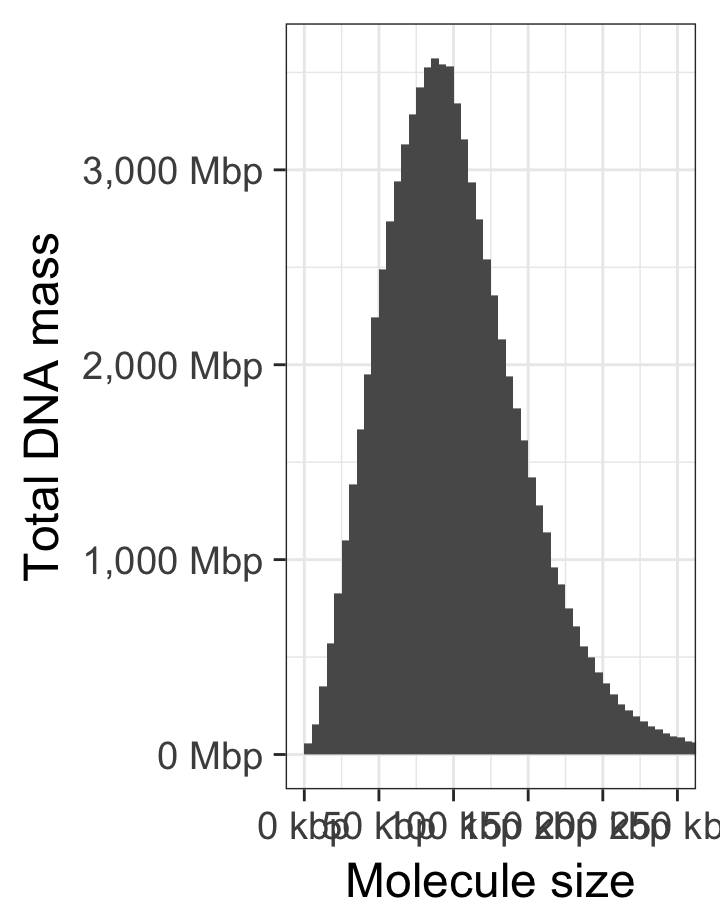

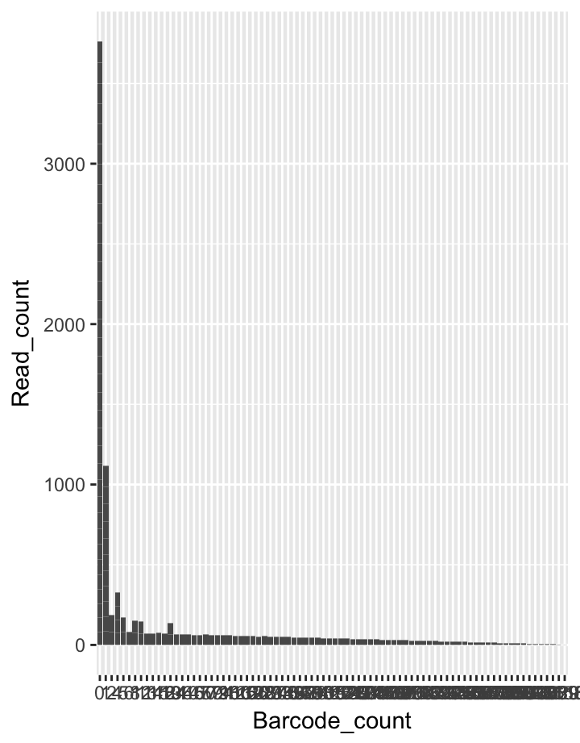

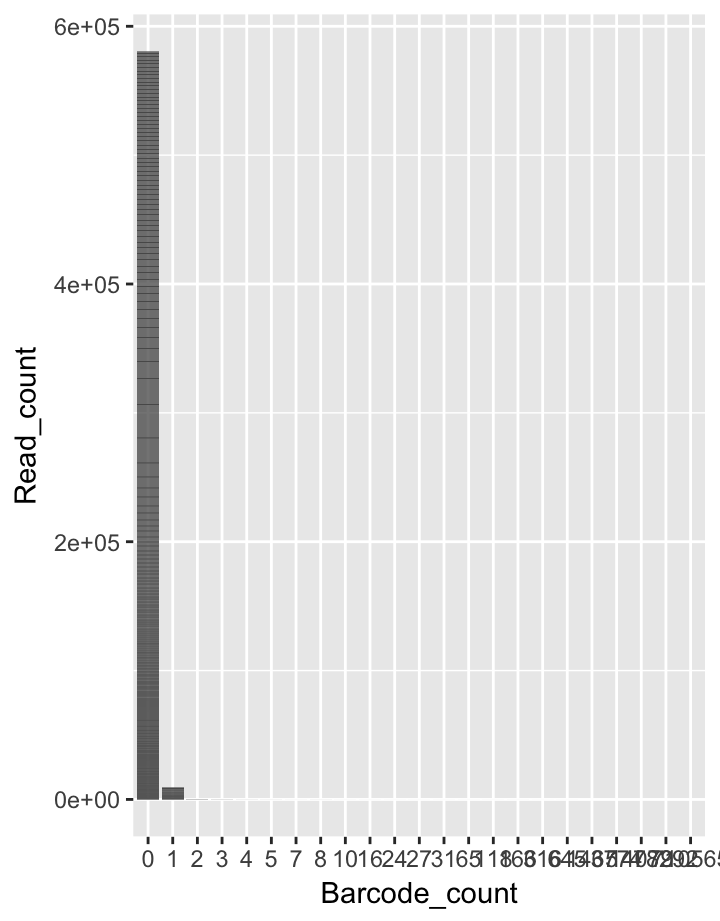

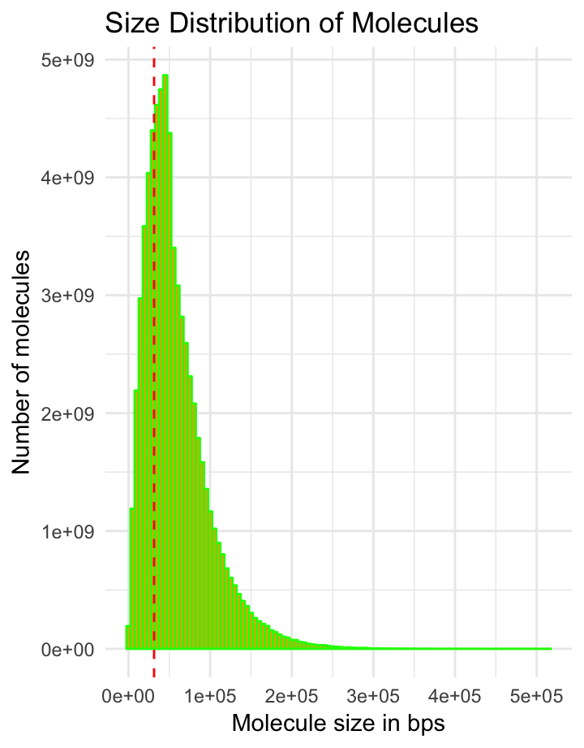

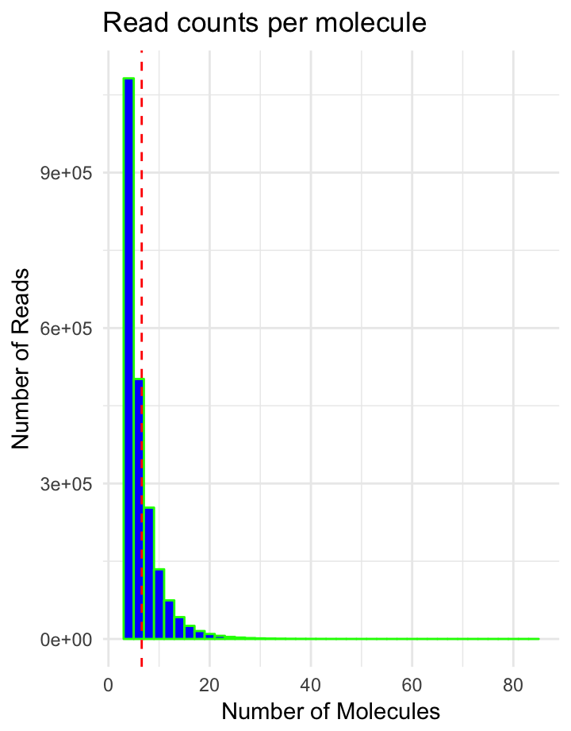

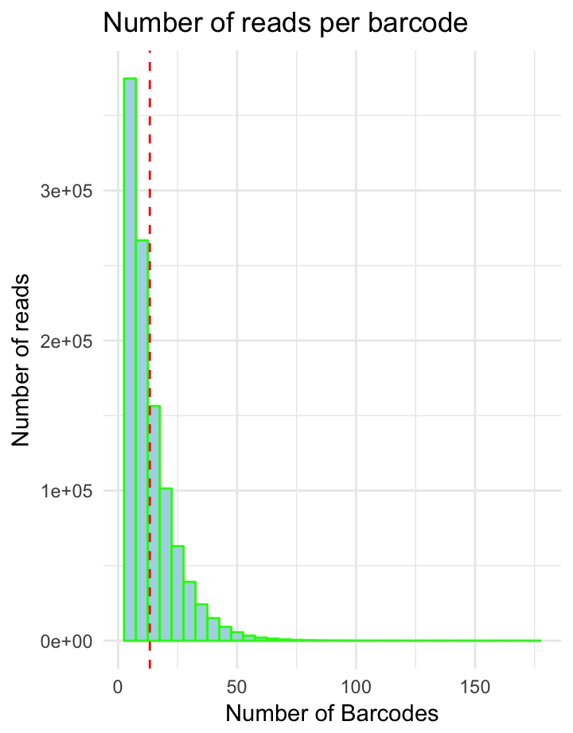

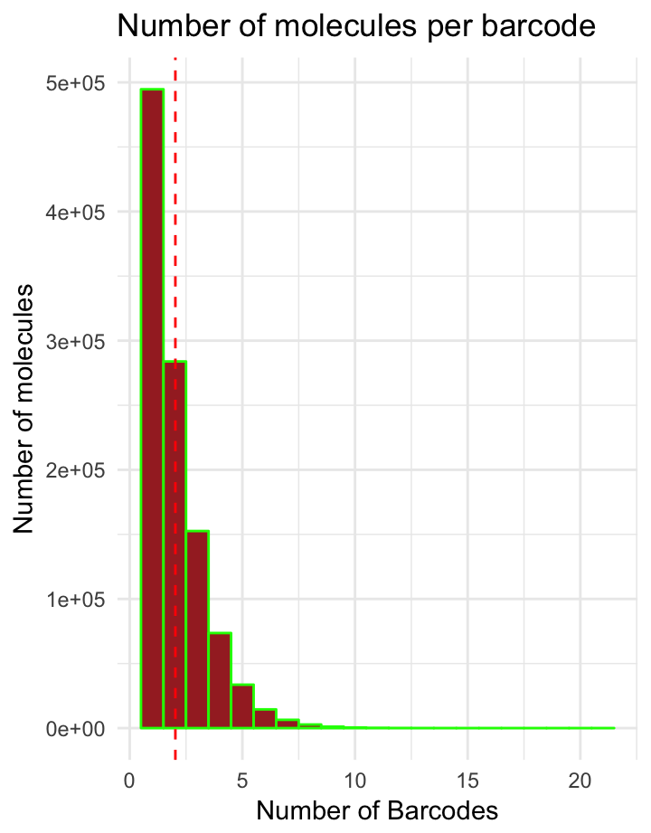

# Summary

### Input DNA

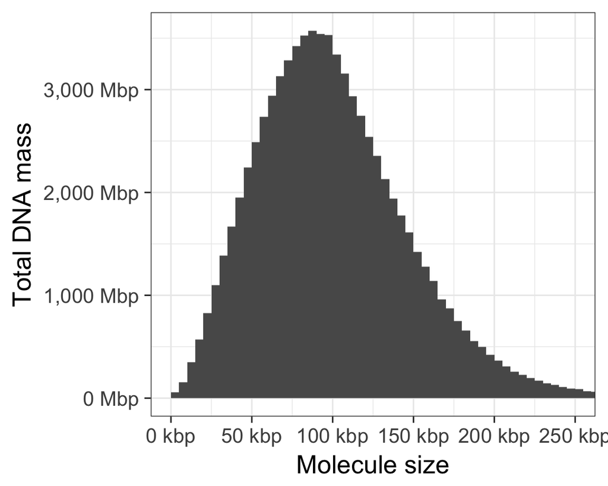

### Molecule size distribution

| Filter | Molecules | Barcodes | N50_LPM | Weighted_mean | N75 | N50 | N25 | Max |
| --- | --- | --- | --- | --- | --- | --- | --- | --- |
| Reads ≥ 4 | 2096037 | 1048350 | 3.5 | 95841.75 | 60956 | 91777 | 125129 | 546118 |
| Reads ≥ 6 | 1062046 | 698167 | 4.5 | 100626.45 | 66726 | 95181 | 127974 | 546118 |

# Long Ranger

File: /Users/sjackman/work/2017_project_6/hg004g1_lrwgsvc/outs/summary.csv

Chromium E00316

Long Ranger v. 2.1.6

**GEMs**

*Number of GEMs* 1,142,731

**INPUT DNA**

*DNA per well* 1.4 ng

*Mean length +/- s.d.* 103 kbp +/- 54 kbp

**BARCODE (BC)**

*Reads with valid BC* 94 %

*Mean base quality score, BC bases* 39

*N50, read-pairs per input DNA molecule* 3

**STRUCTURAL VARIANT CALLS**

*Large SVs* 117

*Deletions* 36

**PHASING**

*Phased SNPs* 42 %

*Genes phased in single phase block* 28 %

*Longest phase block* 344 kb

*N50 length, called phased blocks* 61 kb

**LINKED-READ ALIGNMENT**

*Long Ranger input reads* 28,675,522

*Mapped reads* 0.97

*Median insert size of aligned read pairs* 303

*Mean read depth* 1.2

*Reads marked as PCR duplicates* 1.6 %

*Non-N bases with zero coverage* 41 %

*Aligned bases mapped to target regions* NA %

# Sequencing Quality

### Read 1 Q20

[interactive chart not shown]

### Read 1 Q30

[interactive chart not shown]

### Read 2 Q20

[interactive chart not shown]

### Read 2 Q30

[interactive chart not shown]

### Sample Index Q20

[interactive chart not shown]

### Sample Index Q30

[interactive chart not shown]

### Barcode Q20

[interactive chart not shown]

### Barcode Q30

[interactive chart not shown]

# Barcodes

Chromium E00316

### Read Distribution of Unmatched Barcodes

| Barcode_count | Read_count |
| --- | --- |
| 0 | 580506 |
| 1 | 9111 |
| 2 | 249 |
| 3 | 117 |
| 4 | 47 |
| 5 | 39 |
| 7 | 19 |
| 8 | 33 |
| 10 | 15 |
| 16 | 14 |
| 24 | 13 |
| 27 | 12 |
| 31 | 11 |
| 65 | 10 |
| 118 | 9 |
| 166 | 8 |
| 316 | 7 |
| 645 | 6 |
| 1465 | 5 |
| 3774 | 4 |
| 14079 | 3 |
| 78292 | 2 |
| 710565 | 1 |

### Read Distribution of White-listed Barcodes

| Barcode_count | Read_count |
| --- | --- |
| 0 | 3762 |
| 1 | 1118 |
| 2 | 187 |
| 4 | 328 |
| 5 | 169 |
| 6 | 79 |
| 8 | 153 |
| 12 | 146 |
| 13 | 73 |
| 14 | 72 |
| 15 | 74 |
| 18 | 69 |
| 19 | 137 |
| 24 | 68 |
| 36 | 66 |
| 40 | 64 |
| 46 | 63 |
| 47 | 60 |
| 50 | 65 |
| 57 | 62 |
| 72 | 61 |
| 94 | 59 |
| 98 | 58 |
| 100 | 57 |
| 126 | 56 |
| 132 | 55 |
| 156 | 54 |
| 198 | 52 |
| 207 | 53 |
| 227 | 51 |
| 293 | 50 |
| 306 | 49 |
| 359 | 48 |
| 404 | 47 |
| 489 | 46 |
| 568 | 45 |
| 578 | 44 |
| 738 | 43 |
| 846 | 42 |
| 935 | 41 |
| 1092 | 40 |
| 1264 | 39 |
| 1529 | 38 |
| 1718 | 37 |
| 1991 | 36 |
| 2228 | 35 |
| 2571 | 34 |
| 3016 | 33 |
| 3481 | 32 |
| 3879 | 31 |
| 4498 | 30 |
| 5387 | 29 |
| 6076 | 28 |
| 6993 | 27 |
| 8118 | 26 |
| 9307 | 25 |
| 10779 | 24 |
| 12399 | 23 |
| 14414 | 22 |
| 16226 | 21 |
| 18627 | 20 |
| 21251 | 19 |
| 24352 | 18 |
| 27937 | 17 |
| 31562 | 16 |
| 35650 | 15 |
| 40059 | 14 |
| 45438 | 13 |
| 51036 | 12 |
| 56806 | 11 |
| 63575 | 10 |
| 70800 | 9 |
| 77511 | 8 |
| 85049 | 7 |
| 92205 | 6 |
| 99963 | 5 |
| 106389 | 4 |
| 113158 | 3 |
| 130299 | 2 |
| 266160 | 1 |

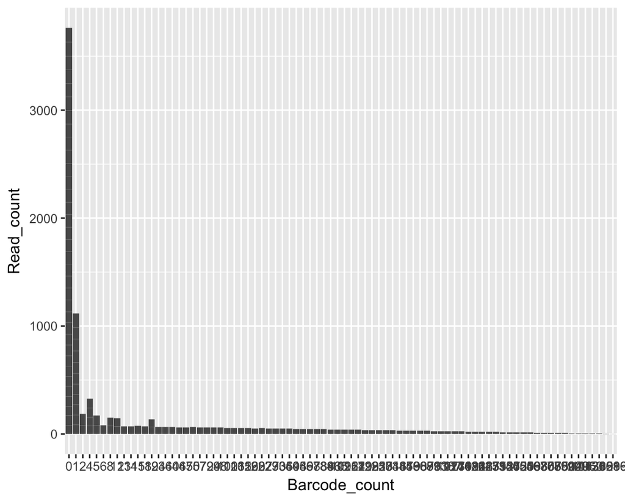

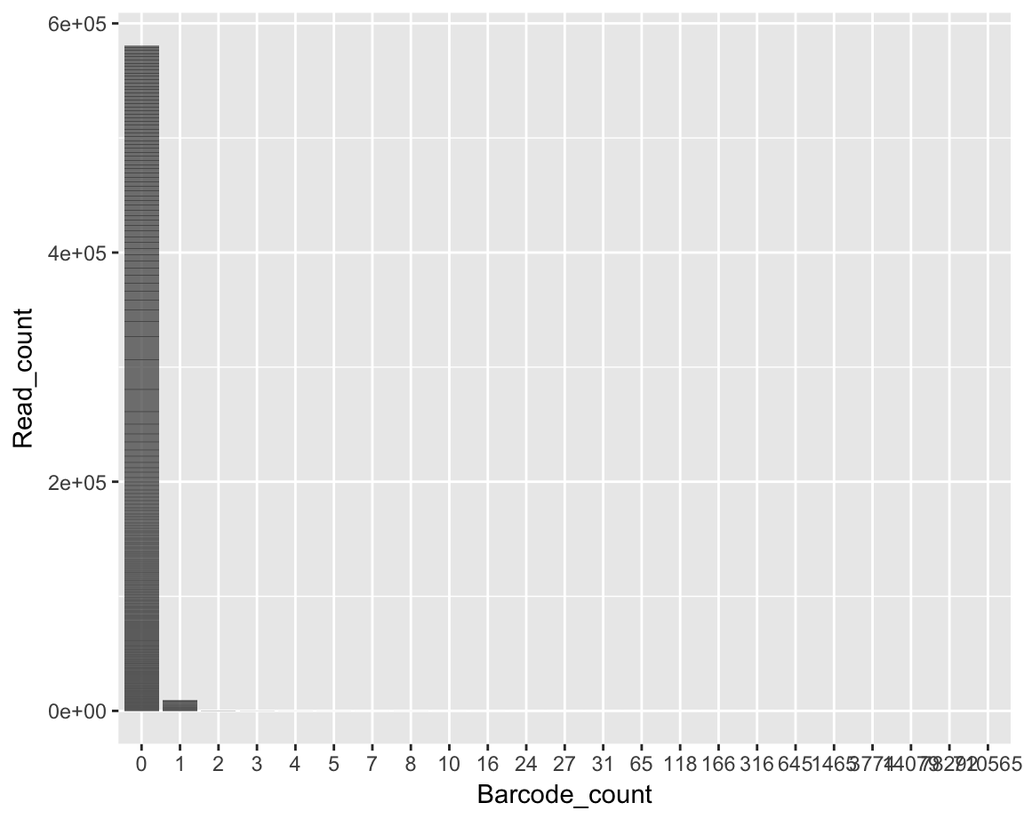

# Molecules

Chromium E00316

Calculations from SAM files

### Size of the molecules

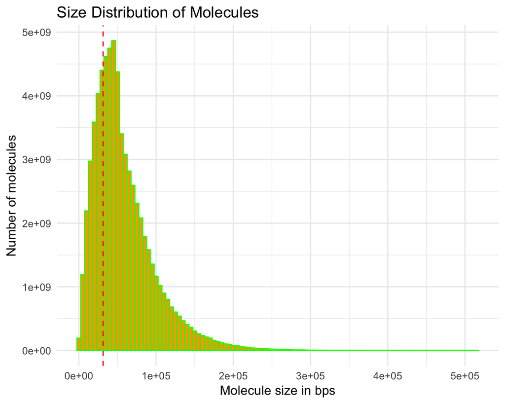

### Number of reads per molecule

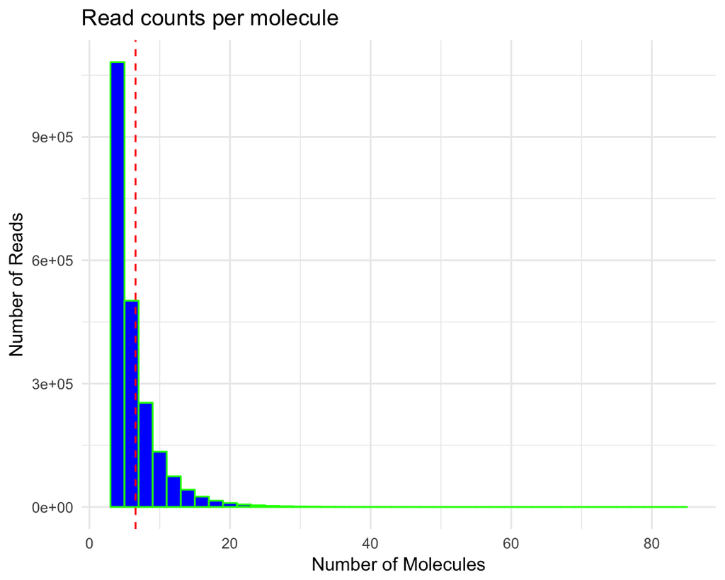

# Number of reads per barcode

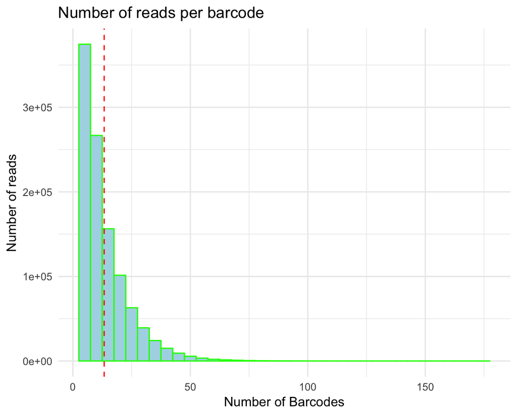

# Number of molecules per barcode

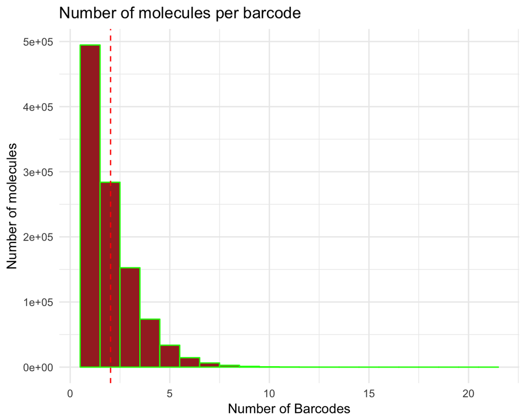